# Prices of Detached Houses

I. N 7184

October 26, 2020

## I. Exploratory Data Analysis

**Use a single plot to describe your data. Create a subset of your data by** **removing at most two cases and briefly explain your choice.**

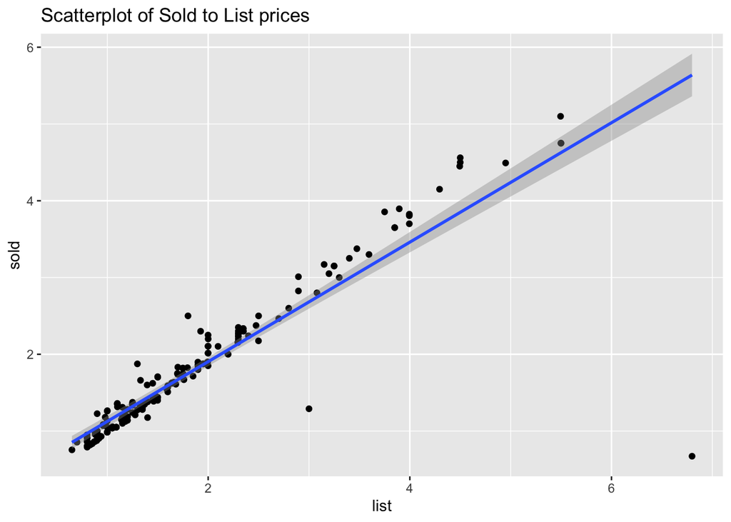

I removed the two outlier points below the line (at around [3, 1.3] and [6.8, 0.7]). At around their given sold prices, their list prices were very large in comparison to the rest, thus affecting the regression line for this data set.

**Then using the data subset for this and the remaining parts of this** **assignment, draw two scatterplots of the response variable- sale price by** **(i) list price and then (ii) taxes. In each plot, distinguish between** **properties in neighbourhood M and those in neighbourhood T, and include a** **legend/key**

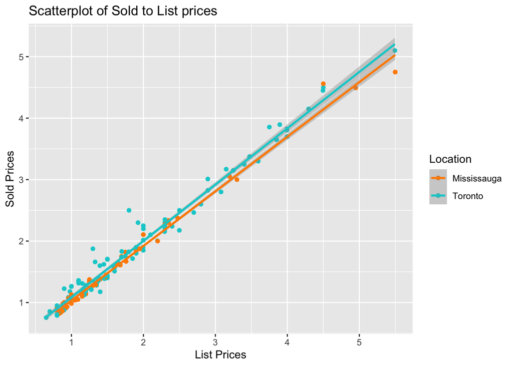

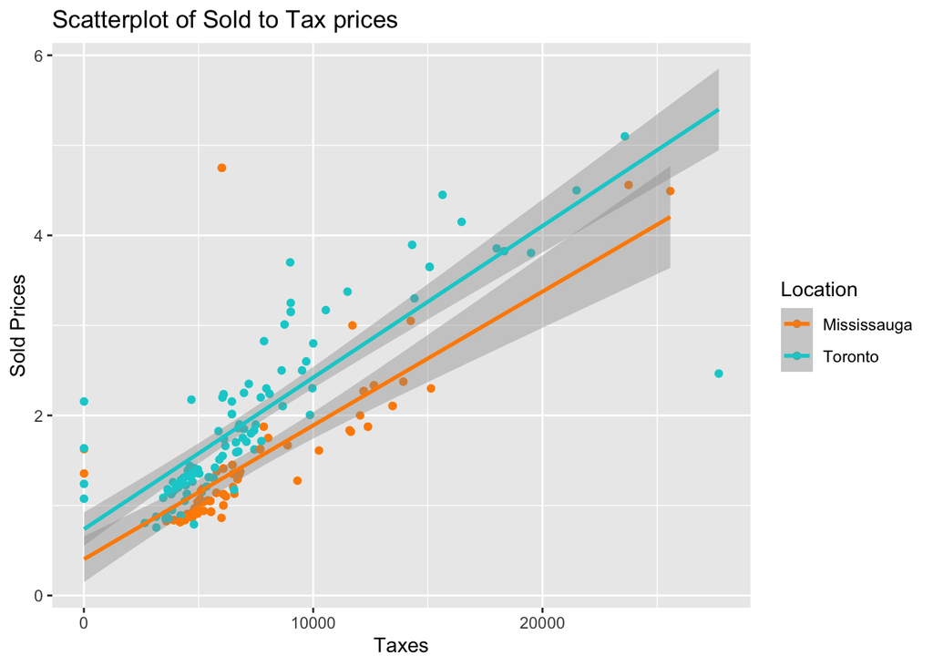

**Interpret each of the three plots produced in this part, that is, describe** **at least one major highlight from each plot. Each highlight should differ** **from the other.**

In the first graph, one highlight we see is that there is an obvious linear trend in the points (apart from two outliers). In the Sold to List prices of the second graph, we see that once the outliers have been removed, the confidence interval (shaded region) has shrunk, meaning the two outliers made a difference in our data. In the Sold to Taxes prices of the third graph, the confidence interval is very large and we also see a more exaggerated difference showing that Toronto homes have a higher sold price than those in Mississauga.

## II. Methods and Model

**Carry out three simple linear regressions (SLR) for sale price from list** **price, one for all data, one for properties of neighbourhood M and another** **for properties of neighbourhood T. In a table, give the values of the** **following for each of these regressions: R squared, the estimated intercept,** **the estimated slope, the estimate of the variance of the error term, the** **p-value for the test with null hypothesis that the slope is 0, a 95%** **confidence interval for the slope parameter**

```
##                                           Total Mississauga     Toronto
## R squared                             9.803e-01   9.893e-01   9.753e-01
## Intercept Estimate                   -1.229e-01  -1.449e-01  -1.330e-01
## Slope Estimate                        1.075e+00   1.114e+00   1.064e+00
## Variance of Error Estimate            2.011e-02   9.730e-03   2.618e-02
## p-value: Null Hypothesis slope = 0   3.376e-169   1.923e-89   3.304e-86
## 95% Confidence Interval Lower Bound   1.054e+00   1.089e+00   1.032e+00
## 95% Confidence Interval Upper Bound   1.097e+00   1.138e+00   1.097e+00
```

**Interpret and compare the three R squared values. Give a brief explanation** **why they appear similar or different**

The three R squared values are relatively high (above 0.975) so, this means that if there are leverage points, they are considered good leverage points. This is because over 97.5% of the data fits the regression model. Because Mississauga homes have a higher R squared than Toronto and the Total, we can say that the regression model fits Mississauga homes better than Toronto homes. A brief graphical explanation as to why they appear similar, is because all of the data originally looked relatively linear (once I removed the two points from above). Their linearity meant that a regression line would fit the data accurately.

**Briefly discuss whether a pooled two-sample t-test can be used to determine** **if there is a statistically significant difference between the slopes of the** **simple linear models for the two neighborhoods. (Note: You do not need to** **carry out a pooled two-sample t- test here.)**

A pooled two-sample t-test cannot be used here to determine if there is a statistically significant difference between the slopes of the simple linear models for the two neighbourhoods. We can use the two-sample t-test to test the difference between the two means but not the two slopes. This is because the two -sample t-test is categorical and not quantitative.

## III. Discussions and Limitations

**A sensible data science approach is to base inferences or conclusions only** **on valid models.**

*Select one of the three fitted models in part II and give a brief* *explanation for your choice.*

I choose to use the Mississauga neighborhood because its R squared value is the greatest. The variance of the error is the lowest and its p-value is less than 0.001 so, there is very strong evidence against the Null Hypothesis. This means that of the three, the data fits the best with this regression line, the errors vary the least, and a very strong suggestion that you can reject this Null Hypothesis for the whole population.

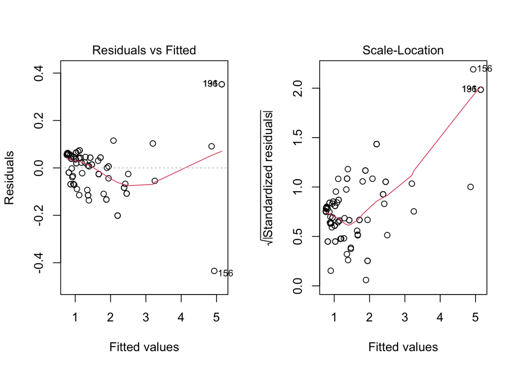

*Identify two potential numeric predictors (other than those given in the data* *set) that could be used to fit a multiple linear regression for sale price.*

1. Distance or Time it takes to commute to work/school
2. Size of Property